# G1S8_project1_Python_gl

```python
import numpy as np
import pandas as pd
import matplotlib.pyplot as plt
%matplotlib inline
import seaborn as sns
import warnings
warnings.filterwarnings('ignore')

import sklearn
from sklearn.preprocessing import StandardScaler,LabelEncoder,MinMaxScaler
```

```python
df=pd.read_csv(r"C:\Users\Tanush Sujoy\Downloads\Dataset and relavant files - Python Project 1\fifa.csv")
df.head()
```

|  | ID | Name | Age | Photo | Nationality | Flag | Overall | Potential | Club | Club Logo | ... | Composure | Marking | StandingTackle | SlidingTackle | GKDiving | GKHandling | GKKicking | GKPositioning | GKReflexes | Release Clause |
| --- | --- | --- | --- | --- | --- | --- | --- | --- | --- | --- | --- | --- | --- | --- | --- | --- | --- | --- | --- | --- | --- |
| 0 | 158023 | L. Messi | 31 | https://cdn.sofifa.org/players/4/19/158023.png | Argentina | https://cdn.sofifa.org/flags/52.png | 94 | 94 | FC Barcelona | https://cdn.sofifa.org/teams/2/light/241.png | ... | 96.0 | 33.0 | 28.0 | 26.0 | 6.0 | 11.0 | 15.0 | 14.0 | 8.0 | €226.5M |
| 1 | 20801 | Cristiano Ronaldo | 33 | https://cdn.sofifa.org/players/4/19/20801.png | Portugal | https://cdn.sofifa.org/flags/38.png | 94 | 94 | Juventus | https://cdn.sofifa.org/teams/2/light/45.png | ... | 95.0 | 28.0 | 31.0 | 23.0 | 7.0 | 11.0 | 15.0 | 14.0 | 11.0 | €127.1M |
| 2 | 190871 | Neymar Jr | 26 | https://cdn.sofifa.org/players/4/19/190871.png | Brazil | https://cdn.sofifa.org/flags/54.png | 92 | 93 | Paris Saint-Germain | https://cdn.sofifa.org/teams/2/light/73.png | ... | 94.0 | 27.0 | 24.0 | 33.0 | 9.0 | 9.0 | 15.0 | 15.0 | 11.0 | €228.1M |
| 3 | 193080 | De Gea | 27 | https://cdn.sofifa.org/players/4/19/193080.png | Spain | https://cdn.sofifa.org/flags/45.png | 91 | 93 | Manchester United | https://cdn.sofifa.org/teams/2/light/11.png | ... | 68.0 | 15.0 | 21.0 | 13.0 | 90.0 | 85.0 | 87.0 | 88.0 | 94.0 | €138.6M |
| 4 | 192985 | K. De Bruyne | 27 | https://cdn.sofifa.org/players/4/19/192985.png | Belgium | https://cdn.sofifa.org/flags/7.png | 91 | 92 | Manchester City | https://cdn.sofifa.org/teams/2/light/10.png | ... | 88.0 | 68.0 | 58.0 | 51.0 | 15.0 | 13.0 | 5.0 | 10.0 | 13.0 | €196.4M |

5 rows × 60 columns

```python
df.shape
```

```
(18207, 60)
```

```python
df.info()
```

```
<class 'pandas.core.frame.DataFrame'>
RangeIndex: 18207 entries, 0 to 18206
Data columns (total 60 columns):
 #   Column                    Non-Null Count  Dtype
---  ------                    --------------  -----
 0   ID                        18207 non-null  int64
 1   Name                      18207 non-null  object
 2   Age                       18207 non-null  int64
 3   Photo                     18207 non-null  object
 4   Nationality               18207 non-null  object
 5   Flag                      18207 non-null  object
 6   Overall                   18207 non-null  int64
 7   Potential                 18207 non-null  int64
 8   Club                      17966 non-null  object
 9   Club Logo                 18207 non-null  object
```

[output cut: 52 more lines]

```python
df.describe()
```

|  | ID | Age | Overall | Potential | International Reputation | Weak Foot | Skill Moves | Jersey Number | Crossing | Finishing | ... | Penalties | Composure | Marking | StandingTackle | SlidingTackle | GKDiving | GKHandling | GKKicking | GKPositioning | GKReflexes |
| --- | --- | --- | --- | --- | --- | --- | --- | --- | --- | --- | --- | --- | --- | --- | --- | --- | --- | --- | --- | --- | --- |
| count | 18207.000000 | 18207.000000 | 18207.000000 | 18207.000000 | 18159.000000 | 18159.000000 | 18159.000000 | 18147.000000 | 18159.000000 | 18159.000000 | ... | 18159.000000 | 18159.000000 | 18159.000000 | 18159.000000 | 18159.000000 | 18159.000000 | 18159.000000 | 18159.000000 | 18159.000000 | 18159.000000 |
| mean | 214298.338606 | 25.122206 | 66.238699 | 71.307299 | 1.113222 | 2.947299 | 2.361308 | 19.546096 | 49.734181 | 45.550911 | ... | 48.548598 | 58.648274 | 47.281623 | 47.697836 | 45.661435 | 16.616223 | 16.391596 | 16.232061 | 16.388898 | 16.710887 |
| std | 29965.244204 | 4.669943 | 6.908930 | 6.136496 | 0.394031 | 0.660456 | 0.756164 | 15.947765 | 18.364524 | 19.525820 | ... | 15.704053 | 11.436133 | 19.904397 | 21.664004 | 21.289135 | 17.695349 | 16.906900 | 16.502864 | 17.034669 | 17.955119 |
| min | 16.000000 | 16.000000 | 46.000000 | 48.000000 | 1.000000 | 1.000000 | 1.000000 | 1.000000 | 5.000000 | 2.000000 | ... | 5.000000 | 3.000000 | 3.000000 | 2.000000 | 3.000000 | 1.000000 | 1.000000 | 1.000000 | 1.000000 | 1.000000 |
| 25% | 200315.500000 | 21.000000 | 62.000000 | 67.000000 | 1.000000 | 3.000000 | 2.000000 | 8.000000 | 38.000000 | 30.000000 | ... | 39.000000 | 51.000000 | 30.000000 | 27.000000 | 24.000000 | 8.000000 | 8.000000 | 8.000000 | 8.000000 | 8.000000 |
| 50% | 221759.000000 | 25.000000 | 66.000000 | 71.000000 | 1.000000 | 3.000000 | 2.000000 | 17.000000 | 54.000000 | 49.000000 | ... | 49.000000 | 60.000000 | 53.000000 | 55.000000 | 52.000000 | 11.000000 | 11.000000 | 11.000000 | 11.000000 | 11.000000 |
| 75% | 236529.500000 | 28.000000 | 71.000000 | 75.000000 | 1.000000 | 3.000000 | 3.000000 | 26.000000 | 64.000000 | 62.000000 | ... | 60.000000 | 67.000000 | 64.000000 | 66.000000 | 64.000000 | 14.000000 | 14.000000 | 14.000000 | 14.000000 | 14.000000 |
| max | 246620.000000 | 45.000000 | 94.000000 | 95.000000 | 5.000000 | 5.000000 | 5.000000 | 99.000000 | 93.000000 | 95.000000 | ... | 92.000000 | 96.000000 | 94.000000 | 93.000000 | 91.000000 | 90.000000 | 92.000000 | 91.000000 | 90.000000 | 94.000000 |

8 rows × 42 columns

```python
df.drop(['Photo','Flag','Club Logo','Jersey Number'],axis=1,inplace=True)
```

```python
df.info()
```

```
<class 'pandas.core.frame.DataFrame'>
RangeIndex: 18207 entries, 0 to 18206
Data columns (total 56 columns):
 #   Column                    Non-Null Count  Dtype
---  ------                    --------------  -----
 0   ID                        18207 non-null  int64
 1   Name                      18207 non-null  object
 2   Age                       18207 non-null  int64
 3   Nationality               18207 non-null  object
 4   Overall                   18207 non-null  int64
 5   Potential                 18207 non-null  int64
 6   Club                      17966 non-null  object
 7   Value                     18207 non-null  object
 8   Wage                      18207 non-null  object
 9   Preferred Foot            18159 non-null  object
```

[output cut: 48 more lines]

```python
df1=df.copy()
```

*Convert the columns "Value", "Wage", "Release Clause" to float datatype after getting rid of currency symbol and suffix. (6 points)*

```python
def EuroConvert(x):
    l=len(x)
    end=x[-1]
    if end=='M':
        value=float(x[1:l-1])*1000000
    elif end=='K':
        value=float(x[1:l-1])*1000
    else:
        value=0
    return value
```

```python
df1['Value']=df1['Value'].apply(lambda x:EuroConvert(x))
df1['Value'].head()
```

```
0    110500000.0
1     77000000.0
2    118500000.0
3     72000000.0
4    102000000.0
Name: Value, dtype: float64
```

```python
df1['Wage']=df1['Wage'].apply(lambda x:EuroConvert(x))
df1['Wage'].head()
```

```
0    565000.0
1    405000.0
2    290000.0
3    260000.0
4    355000.0
Name: Wage, dtype: float64
```

```python
df1['Release Clause'].fillna("None",inplace=True)
df1['Release Clause']=df1['Release Clause'].apply(lambda x:EuroConvert(x))
df1['Release Clause'].head()
```

```
0    226500000.0
1    127100000.0
2    228100000.0
3    138600000.0
4    196400000.0
Name: Release Clause, dtype: float64
```

```python
df1[['Value','Wage','Release Clause']].head()
```

|  | Value | Wage | Release Clause |
| --- | --- | --- | --- |
| 0 | 110500000.0 | 565000.0 | 226500000.0 |
| 1 | 77000000.0 | 405000.0 | 127100000.0 |
| 2 | 118500000.0 | 290000.0 | 228100000.0 |
| 3 | 72000000.0 | 260000.0 | 138600000.0 |
| 4 | 102000000.0 | 355000.0 | 196400000.0 |

*The column 'Height' is in inches with a quotation mark, Convert to float with decimal points. (2 points)

1. The column "Weight" has the suffix as lbs, remove the suffix and convert to float. (2 points)*

```python
def clean_height(x):
    if isinstance(x,str):
        return(x.replace("'",'.').replace(',',''))
    return(x)
```

```python
df1['Height']=df1['Height'].apply(clean_height)
df1['Height']=df1['Height'].astype('float')
```

```python
df1['Height'].info()
```

```
<class 'pandas.core.series.Series'>
RangeIndex: 18207 entries, 0 to 18206
Series name: Height
Non-Null Count  Dtype
--------------  -----
18159 non-null  float64
dtypes: float64(1)
memory usage: 142.4 KB
```

```python
def clean_weight(x):
    if isinstance(x,str):
        return(x.replace('lbs','').replace(',',''))
    return(x)
```

```python
df1['Weight']=df1['Weight'].apply(clean_weight)
df1['Weight']=df1['Weight'].astype('float')
```

```python
df1['Weight'].info()
```

```
<class 'pandas.core.series.Series'>
RangeIndex: 18207 entries, 0 to 18206
Series name: Weight
Non-Null Count  Dtype
--------------  -----
18159 non-null  float64
dtypes: float64(1)
memory usage: 142.4 KB
```

*Convert the column "Joined" into integer data type with keeping only the year. (2 points)*

```python
df1.Joined=pd.to_datetime(df1.Joined)
df1['Joined']=df1.Joined.dt.year
df1['Joined']=df1.Joined.fillna(0).astype(int)
```

```python
df1.Joined.head()
```

```
0    2004
1    2018
2    2017
3    2011
4    2015
Name: Joined, dtype: int32
```

*Convert the column "Contract Valid Until" to pandas datetime type*

```python
df1['Contract Valid Until']=pd.to_datetime(df1['Contract Valid Until'])
```

```python
df1['Contract Valid Until'].head()
```

```
0   2021-01-01
1   2022-01-01
2   2022-01-01
3   2020-01-01
4   2023-01-01
Name: Contract Valid Until, dtype: datetime64[ns]
```

```python
df1.info()
```

```
<class 'pandas.core.frame.DataFrame'>
RangeIndex: 18207 entries, 0 to 18206
Data columns (total 56 columns):
 #   Column                    Non-Null Count  Dtype
---  ------                    --------------  -----
 0   ID                        18207 non-null  int64
 1   Name                      18207 non-null  object
 2   Age                       18207 non-null  int64
 3   Nationality               18207 non-null  object
 4   Overall                   18207 non-null  int64
 5   Potential                 18207 non-null  int64
 6   Club                      17966 non-null  object
 7   Value                     18207 non-null  float64
 8   Wage                      18207 non-null  float64
 9   Preferred Foot            18159 non-null  object
```

[output cut: 48 more lines]

*Check for the percentage of missing values and impute them with appropriate imputation techniques*

```python
df1.isnull().sum()
```

```
ID                              0
Name                            0
Age                             0
Nationality                     0
Overall                         0
Potential                       0
Club                          241
Value                           0
Wage                            0
Preferred Foot                 48
International Reputation       48
Weak Foot                      48
Skill Moves                    48
Work Rate                      48
Body Type                      48
Position                       60
Joined                          0
Loaned From                 16943
Contract Valid Until          289
Height                         48
Weight                         48
Crossing                       48
Finishing                      48
HeadingAccuracy                48
ShortPassing                   48
Volleys                        48
Dribbling                      48
Curve                          48
FKAccuracy                     48
LongPassing                    48
BallControl                    48
Acceleration                   48
SprintSpeed                    48
Agility                        48
Reactions                      48
Balance                        48
ShotPower                      48
Jumping                        48
Stamina                        48
Strength                       48
LongShots                      48
Aggression                     48
Interceptions                  48
Positioning                    48
Vision                         48
Penalties                      48
Composure                      48
Marking                        48
StandingTackle                 48
SlidingTackle                  48
GKDiving                       48
GKHandling                     48
GKKicking                      48
GKPositioning                  48
GKReflexes                     48
Release Clause                  0
dtype: int64
```

*We can drop Loaned from as it has a lot of null values & also it won't affect the selection of players*

```python
df1.drop(['Loaned From'],axis=1,inplace=True)
```

```python
percent_missing=(df1.isnull().sum().sort_values(ascending=False)*100/len(df1)).round(2)
percent_missing
```

```
Contract Valid Until        1.59
Club                        1.32
Position                    0.33
FKAccuracy                  0.26
Reactions                   0.26
Curve                       0.26
Marking                     0.26
LongPassing                 0.26
BallControl                 0.26
Acceleration                0.26
SprintSpeed                 0.26
Agility                     0.26
Balance                     0.26
Volleys                     0.26
ShotPower                   0.26
Jumping                     0.26
Stamina                     0.26
Strength                    0.26
LongShots                   0.26
Aggression                  0.26
Interceptions               0.26
Positioning                 0.26
Vision                      0.26
Dribbling                   0.26
HeadingAccuracy             0.26
ShortPassing                0.26
Composure                   0.26
GKReflexes                  0.26
GKPositioning               0.26
GKKicking                   0.26
GKHandling                  0.26
GKDiving                    0.26
SlidingTackle               0.26
Preferred Foot              0.26
International Reputation    0.26
Weak Foot                   0.26
Skill Moves                 0.26
Work Rate                   0.26
Body Type                   0.26
StandingTackle              0.26
Height                      0.26
Weight                      0.26
Crossing                    0.26
Finishing                   0.26
Penalties                   0.26
ID                          0.00
Name                        0.00
Joined                      0.00
Wage                        0.00
Value                       0.00
Potential                   0.00
Overall                     0.00
Nationality                 0.00
Age                         0.00
Release Clause              0.00
dtype: float64
```

*Check for duplicated value*

```python
len(df[df.duplicated()])
```

```
0
```

```python
#grouping numerical values
numerical_attributes=list(df1.describe())
numerical_attributes
```

```
['ID',
 'Age',
 'Overall',
 'Potential',
 'Value',
 'Wage',
 'International Reputation',
 'Weak Foot',
 'Skill Moves',
 'Joined',
 'Height',
 'Weight',
 'Crossing',
 'Finishing',
 'HeadingAccuracy',
 'ShortPassing',
 'Volleys',
 'Dribbling',
 'Curve',
 'FKAccuracy',
 'LongPassing',
 'BallControl',
 'Acceleration',
 'SprintSpeed',
 'Agility',
 'Reactions',
 'Balance',
 'ShotPower',
 'Jumping',
 'Stamina',
 'Strength',
 'LongShots',
 'Aggression',
 'Interceptions',
 'Positioning',
 'Vision',
 'Penalties',
 'Composure',
 'Marking',
 'StandingTackle',
 'SlidingTackle',
 'GKDiving',
 'GKHandling',
 'GKKicking',
 'GKPositioning',
 'GKReflexes',
 'Release Clause']
```

```python
#Replace/impute missing values with mean#we will group all numeric attributes and fill missing value with mean
#grouping numerical values
#
for attribute in numerical_attributes:
    df1[attribute].fillna(df1[attribute].mean(), inplace=True)
```

```python
#Replace the categorical values with value 'not known'
categorical_attributes=['Club','Preferred Foot','Body Type','Contract Valid Until','Position','Work Rate']
for attribute in categorical_attributes:
    df1[attribute].fillna(value='Not Known',inplace=True)
```

```python
percent_missing=(df1.isnull().sum().sort_values(ascending=False)*100/len(df1)).round(2)
percent_missing
```

```
ID                          0.0
Interceptions               0.0
Acceleration                0.0
SprintSpeed                 0.0
Agility                     0.0
Reactions                   0.0
Balance                     0.0
ShotPower                   0.0
Jumping                     0.0
Stamina                     0.0
Strength                    0.0
LongShots                   0.0
Aggression                  0.0
Positioning                 0.0
LongPassing                 0.0
Vision                      0.0
Penalties                   0.0
Composure                   0.0
Marking                     0.0
StandingTackle              0.0
SlidingTackle               0.0
GKDiving                    0.0
GKHandling                  0.0
GKKicking                   0.0
GKPositioning               0.0
GKReflexes                  0.0
BallControl                 0.0
FKAccuracy                  0.0
Name                        0.0
Work Rate                   0.0
Age                         0.0
Nationality                 0.0
Overall                     0.0
Potential                   0.0
Club                        0.0
Value                       0.0
Wage                        0.0
Preferred Foot              0.0
International Reputation    0.0
Weak Foot                   0.0
Skill Moves                 0.0
Body Type                   0.0
Curve                       0.0
Position                    0.0
Joined                      0.0
Contract Valid Until        0.0
Height                      0.0
Weight                      0.0
Crossing                    0.0
Finishing                   0.0
HeadingAccuracy             0.0
ShortPassing                0.0
Volleys                     0.0
Dribbling                   0.0
Release Clause              0.0
dtype: float64
```

*Exploratory Data Analysis*

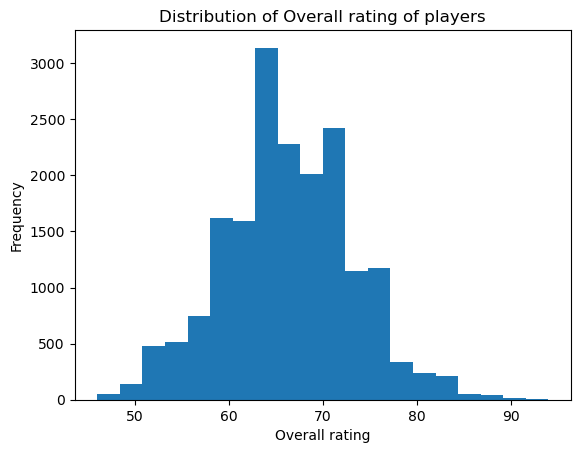

```python
#Plot the distribution of Overall rating for all the players and write your
#findings. (2 points)
df1['Overall'].plot(kind='hist',bins=20)
plt.xlabel('Overall rating')
plt.ylabel('Frequency')
plt.title('Distribution of Overall rating of players')
plt.show()
```

```python
#Retrieve the names of top20 players based on the Overall rating. (2 points)
top_20_players = df1.sort_values(by='Overall', ascending=False).head(20)
top_20_players['Name']
```

```
0              L. Messi
1     Cristiano Ronaldo
2             Neymar Jr
3                De Gea
4          K. De Bruyne
5             E. Hazard
6             L. Modrić
7             L. Suárez
8          Sergio Ramos
12             D. Godín
13          David Silva
9              J. Oblak
11             T. Kroos
10       R. Lewandowski
20      Sergio Busquets
24         G. Chiellini
23            S. Agüero
22             M. Neuer
21            E. Cavani
16              H. Kane
Name: Name, dtype: object
```

```python
#Generate a dataframe which should include all the information of the
#Top 20 players based on the Overall rating. (4 points)
df1_top_20_players=top_20_players.copy()
df1_top_20_players
```

|  | ID | Name | Age | Nationality | Overall | Potential | Club | Value | Wage | Preferred Foot | ... | Composure | Marking | StandingTackle | SlidingTackle | GKDiving | GKHandling | GKKicking | GKPositioning | GKReflexes | Release Clause |
| --- | --- | --- | --- | --- | --- | --- | --- | --- | --- | --- | --- | --- | --- | --- | --- | --- | --- | --- | --- | --- | --- |
| 0 | 158023 | L. Messi | 31 | Argentina | 94 | 94 | FC Barcelona | 110500000.0 | 565000.0 | Left | ... | 96.0 | 33.0 | 28.0 | 26.0 | 6.0 | 11.0 | 15.0 | 14.0 | 8.0 | 226500000.0 |
| 1 | 20801 | Cristiano Ronaldo | 33 | Portugal | 94 | 94 | Juventus | 77000000.0 | 405000.0 | Right | ... | 95.0 | 28.0 | 31.0 | 23.0 | 7.0 | 11.0 | 15.0 | 14.0 | 11.0 | 127100000.0 |
| 2 | 190871 | Neymar Jr | 26 | Brazil | 92 | 93 | Paris Saint-Germain | 118500000.0 | 290000.0 | Right | ... | 94.0 | 27.0 | 24.0 | 33.0 | 9.0 | 9.0 | 15.0 | 15.0 | 11.0 | 228100000.0 |
| 3 | 193080 | De Gea | 27 | Spain | 91 | 93 | Manchester United | 72000000.0 | 260000.0 | Right | ... | 68.0 | 15.0 | 21.0 | 13.0 | 90.0 | 85.0 | 87.0 | 88.0 | 94.0 | 138600000.0 |
| 4 | 192985 | K. De Bruyne | 27 | Belgium | 91 | 92 | Manchester City | 102000000.0 | 355000.0 | Right | ... | 88.0 | 68.0 | 58.0 | 51.0 | 15.0 | 13.0 | 5.0 | 10.0 | 13.0 | 196400000.0 |
| 5 | 183277 | E. Hazard | 27 | Belgium | 91 | 91 | Chelsea | 93000000.0 | 340000.0 | Right | ... | 91.0 | 34.0 | 27.0 | 22.0 | 11.0 | 12.0 | 6.0 | 8.0 | 8.0 | 172100000.0 |
| 6 | 177003 | L. Modrić | 32 | Croatia | 91 | 91 | Real Madrid | 67000000.0 | 420000.0 | Right | ... | 84.0 | 60.0 | 76.0 | 73.0 | 13.0 | 9.0 | 7.0 | 14.0 | 9.0 | 137400000.0 |
| 7 | 176580 | L. Suárez | 31 | Uruguay | 91 | 91 | FC Barcelona | 80000000.0 | 455000.0 | Right | ... | 85.0 | 62.0 | 45.0 | 38.0 | 27.0 | 25.0 | 31.0 | 33.0 | 37.0 | 164000000.0 |
| 8 | 155862 | Sergio Ramos | 32 | Spain | 91 | 91 | Real Madrid | 51000000.0 | 380000.0 | Right | ... | 82.0 | 87.0 | 92.0 | 91.0 | 11.0 | 8.0 | 9.0 | 7.0 | 11.0 | 104600000.0 |
| 12 | 182493 | D. Godín | 32 | Uruguay | 90 | 90 | Atlético Madrid | 44000000.0 | 125000.0 | Right | ... | 82.0 | 90.0 | 89.0 | 89.0 | 6.0 | 8.0 | 15.0 | 5.0 | 15.0 | 90200000.0 |
| 13 | 168542 | David Silva | 32 | Spain | 90 | 90 | Manchester City | 60000000.0 | 285000.0 | Left | ... | 93.0 | 59.0 | 53.0 | 29.0 | 6.0 | 15.0 | 7.0 | 6.0 | 12.0 | 111000000.0 |
| 9 | 200389 | J. Oblak | 25 | Slovenia | 90 | 93 | Atlético Madrid | 68000000.0 | 94000.0 | Right | ... | 70.0 | 27.0 | 12.0 | 18.0 | 86.0 | 92.0 | 78.0 | 88.0 | 89.0 | 144500000.0 |
| 11 | 182521 | T. Kroos | 28 | Germany | 90 | 90 | Real Madrid | 76500000.0 | 355000.0 | Right | ... | 85.0 | 72.0 | 79.0 | 69.0 | 10.0 | 11.0 | 13.0 | 7.0 | 10.0 | 156800000.0 |
| 10 | 188545 | R. Lewandowski | 29 | Poland | 90 | 90 | FC Bayern München | 77000000.0 | 205000.0 | Right | ... | 86.0 | 34.0 | 42.0 | 19.0 | 15.0 | 6.0 | 12.0 | 8.0 | 10.0 | 127100000.0 |
| 20 | 189511 | Sergio Busquets | 29 | Spain | 89 | 89 | FC Barcelona | 51500000.0 | 315000.0 | Right | ... | 90.0 | 90.0 | 86.0 | 80.0 | 5.0 | 8.0 | 13.0 | 9.0 | 13.0 | 105600000.0 |
| 24 | 138956 | G. Chiellini | 33 | Italy | 89 | 89 | Juventus | 27000000.0 | 215000.0 | Left | ... | 84.0 | 93.0 | 93.0 | 90.0 | 3.0 | 3.0 | 2.0 | 4.0 | 3.0 | 44600000.0 |
| 23 | 153079 | S. Agüero | 30 | Argentina | 89 | 89 | Manchester City | 64500000.0 | 300000.0 | Right | ... | 90.0 | 30.0 | 20.0 | 12.0 | 13.0 | 15.0 | 6.0 | 11.0 | 14.0 | 119300000.0 |
| 22 | 167495 | M. Neuer | 32 | Germany | 89 | 89 | FC Bayern München | 38000000.0 | 130000.0 | Right | ... | 70.0 | 17.0 | 10.0 | 11.0 | 90.0 | 86.0 | 91.0 | 87.0 | 87.0 | 62700000.0 |
| 21 | 179813 | E. Cavani | 31 | Uruguay | 89 | 89 | Paris Saint-Germain | 60000000.0 | 200000.0 | Right | ... | 82.0 | 52.0 | 45.0 | 39.0 | 12.0 | 5.0 | 13.0 | 13.0 | 10.0 | 111000000.0 |
| 16 | 202126 | H. Kane | 24 | England | 89 | 91 | Tottenham Hotspur | 83500000.0 | 205000.0 | Right | ... | 89.0 | 56.0 | 36.0 | 38.0 | 8.0 | 10.0 | 11.0 | 14.0 | 11.0 | 160700000.0 |

20 rows × 55 columns

```python
#14.What is the average "Age" and "Wage" of these top 20 players? (use
#the data frame created in the question 11) (2 points)
Average_Age=df1_top_20_players['Age'].mean()
Average_Wage=df1_top_20_players['Wage'].mean()
print('The average age of top 20 palyers:',Average_Age)
print('The average age of top 20 palyers:',Average_Wage)
```

[output not shown]

1. i) find the average Overall rating for each club.
2. ii) Display the average overall rating of Top10 Clubs using a plot*

```python
New_df1=(df1[['Name','Club','Overall','Wage']])
print(New_df1.head())
```

```
                Name                 Club  Overall      Wage
0           L. Messi         FC Barcelona       94  565000.0
1  Cristiano Ronaldo             Juventus       94  405000.0
2          Neymar Jr  Paris Saint-Germain       92  290000.0
3             De Gea    Manchester United       91  260000.0
4       K. De Bruyne      Manchester City       91  355000.0
```

# 15)i.find the average Overall rating for each clubi

```python
Club_Rating=New_df1.groupby('Club')['Overall'].mean()
Club_Rating.head()
```

```
Club
 SSV Jahn Regensburg     65.586207
1. FC Heidenheim 1846    65.750000
1. FC Kaiserslautern     63.384615
1. FC Köln               70.785714
1. FC Magdeburg          65.615385
Name: Overall, dtype: float64
```

Display the average overall rating of Top10 Clubs using a plot*

```python
Top10_Clubs=Club_Rating.nlargest(10)
Top10_Clubs
```

```
Club
Juventus               82.280000
Napoli                 80.000000
Inter                  79.750000
Real Madrid            78.242424
Milan                  78.074074
FC Barcelona           78.030303
Paris Saint-Germain    77.433333
Roma                   77.423077
Manchester United      77.242424
FC Bayern München      77.000000
Name: Overall, dtype: float64
```

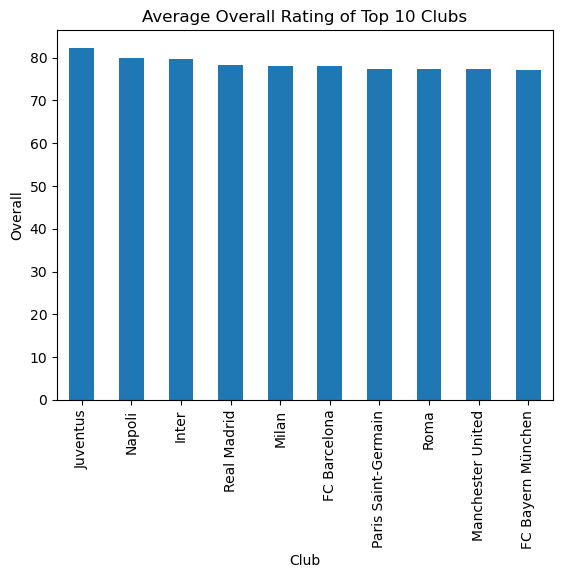

```python
#15.ii)Display the average overall rating of Top10 Clubs using a plot
Top10_Clubs.plot(kind='bar')
plt.xlabel('Club')
plt.ylabel('Overall')
plt.title('Average Overall Rating of Top 10 Clubs')
plt.show()
```

*16.What is the relationship between age and individual potential of the player? Visualize the relationship with appropriate plot and Comment on the same. (2 points)*

```python
df1[['Age','Potential']].corr()
```

|  | Age | Potential |
| --- | --- | --- |
| Age | 1.000000 | -0.253312 |
| Potential | -0.253312 | 1.000000 |

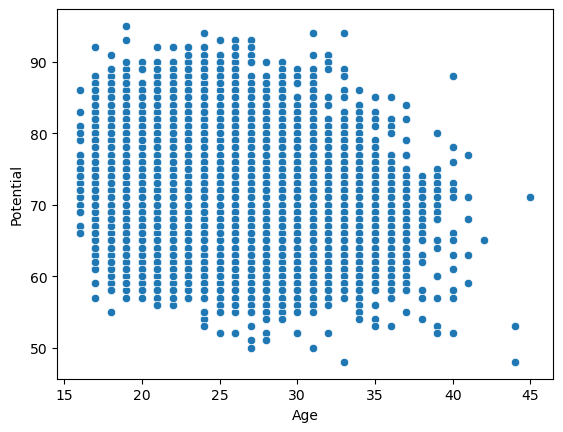

```python
sns.scatterplot(x='Age',y='Potential',data=df1)
plt.title='Relationshio between Age and Potential'
plt.show()
```

Between the age of 21 to 34 the potential of the player is at peak,after 35 the potential declines.

#### 17.Which features directly contribute to the wages of the players?

Support your answer with a plot and a metric. (2 points) (hint: use potential, Overall, value, international reputation, and Release Clause)

```python
selected_attributes=df1[['Wage','Potential','Overall','Value','International Reputation','Release Clause']].corr()
selected_attributes
```

|  | Wage | Potential | Overall | Value | International Reputation | Release Clause |
| --- | --- | --- | --- | --- | --- | --- |
| Wage | 1.000000 | 0.486413 | 0.571926 | 0.858442 | 0.668515 | 0.820162 |
| Potential | 0.486413 | 1.000000 | 0.660939 | 0.576218 | 0.372375 | 0.547668 |
| Overall | 0.571926 | 0.660939 | 1.000000 | 0.627085 | 0.499243 | 0.589200 |
| Value | 0.858442 | 0.576218 | 0.627085 | 1.000000 | 0.653059 | 0.967255 |
| International Reputation | 0.668515 | 0.372375 | 0.499243 | 0.653059 | 1.000000 | 0.617969 |
| Release Clause | 0.820162 | 0.547668 | 0.589200 | 0.967255 | 0.617969 | 1.000000 |

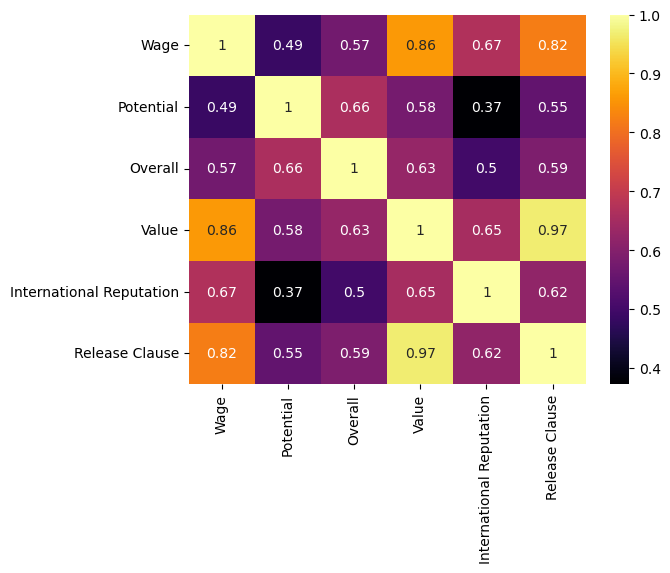

```python
sns.heatmap(selected_attributes,annot=True,cmap='inferno')
```

We can tell that Value and Release Clause is directly contribute to wages of players